# Week 2 Slides

## Arranging Data

- Often need to manipulate data in tibbles in various ways
- Such manipulations might include:
  - Filtering out certain rows
  - Renaming poorly named columns
  - Deriving new columns using the values in others
  - Changing the order of rows etc.
- These operations may collectively be termed *arranging* the data
- Many provided in the *[`dplyr` package](https://dplyr.tidyverse.org/)

## Arranging Data - `dplyr::mutate()`

## `dplyr::mutate()` - Create new columns using other columns

- Sometimes we want to create new columns derived from other columns
- Example: [Multiple testing correction](https://en.wikipedia.org/wiki/Multiple_comparisons_problem)
- Adjusts nominal p-values to account for the number of tests that are significant simply bu chance
- [Benjamini-Hochberg or False Discovery Rate (FDR)](https://en.wikipedia.org/wiki/False_discovery_rate) procedure, a common procedure
- `p.adjust` function can perform several of these procedures, including FDR

## Made up gene statistics example

- Consider the following tibble with made up gene information

```r
gene_stats
```

```
## # A tibble: 4 × 5
##   gene  test1_stat test1_p test2_stat  test2_p
##   <chr>      <dbl>   <dbl>      <dbl>    <dbl>
## 1 hoxd1      12.5  0.103       34.2   0.000013
## 2 brca1       4.40 0.632       16.3   0.0421
## 3 brca2       9.67 0.932       12.7   0.0621
## 4 snca       45.7  0.00042      0.757 0.915
```

## `dplyr::mutate()` - FDR example

```r
gene_stats <- dplyr::mutate(gene_stats,
  test1_padj=p.adjust(test1_p,method="fdr")
)
gene_stats
```

```
## # A tibble: 4 × 6
##   gene  test1_stat test1_p test2_stat  test2_p test1_padj
##   <chr>      <dbl>   <dbl>      <dbl>    <dbl>      <dbl>
## 1 hoxd1      12.5  0.103       34.2   0.000013    0.206
## 2 brca1       4.40 0.632       16.3   0.0421      0.843
## 3 brca2       9.67 0.932       12.7   0.0621      0.932
## 4 snca       45.7  0.00042      0.757 0.915       0.00168
```

## `dplyr::mutate()` - FDR example

- You can create multiple columns in the same call to `mutate()`:

  ```r
  gene_stats <- dplyr::mutate(gene_stats,
    test1_padj=p.adjust(test1_p,method="fdr"),
    test2_padj=p.adjust(test2_p,method="fdr")
  )
  gene_stats
  ```

  ```
  ## # A tibble: 4 × 7
  ##   gene  test1_stat test1_p test2_stat  test2_p test1_padj test2_padj
  ##   <chr>      <dbl>   <dbl>      <dbl>    <dbl>      <dbl>      <dbl>
  ## 1 hoxd1      12.5  0.103       34.2   0.000013    0.206     0.000052
  ## 2 brca1       4.40 0.632       16.3   0.0421      0.843     0.0828
  ## 3 brca2       9.67 0.932       12.7   0.0621      0.932     0.0828
  ## 4 snca       45.7  0.00042      0.757 0.915       0.00168   0.915
  ```

## `dplyr::mutate()` - Deriving from multiple columns

- Here we create a column with `TRUE` or `FALSE` if either or both of the adjusted p-values are less than \(0.05\):

  ```r
  gene_stats <- dplyr::mutate(gene_stats,
    signif_either=(test1_padj < 0.05 | test2_padj < 0.05),
    signif_both=(test1_padj < 0.05 & test2_padj < 0.05)
  )
  ```

- `|` and `&` operators execute ‘or’ and ‘and’ logic, respectively

## `dplyr::mutate()` - using derived columns

- Columns created first in a `mutate()` call can be used in subsequent column definitions:

```r
gene_stats <- dplyr::mutate(gene_stats,
  test1_padj=p.adjust(test1_p,method="fdr"), # test1_padj created
  test2_padj=p.adjust(test2_p,method="fdr"),
  signif_either=(test1_padj < 0.05 | test2_padj < 0.05), #test1_padj used
  signif_both=(test1_padj < 0.05 & test2_padj < 0.05)
)
```

## `dplyr::mutate()` - Modifying columns

- `mutate()` can also be used to modify columns in place
- Example replaces the values in the `gene` column with upper cased values

  ```r
  dplyr::mutate(gene_stats, gene=stringr::str_to_upper(gene) )
  ```

  ```
  ## # A tibble: 4 × 9
  ##   gene  test1_stat test1_p test2_stat  test2_p test1_padj test2_padj
  ##   <chr>      <dbl>   <dbl>      <dbl>    <dbl>      <dbl>      <dbl>
  ## 1 HOXD1      12.5  0.103       34.2   0.000013    0.206     0.000052
  ## 2 BRCA1       4.40 0.632       16.3   0.0421      0.843     0.0828
  ## 3 BRCA2       9.67 0.932       12.7   0.0621      0.932     0.0828
  ## 4 SNCA       45.7  0.00042      0.757 0.915       0.00168   0.915
  ## # ℹ 2 more variables: signif_either <lgl>, signif_both <lgl>
  ```

## Arranging Data - `dplyr::filter()`

## `dplyr::filter()` - Pick rows out of a data set

- Consider the following tibble with made up gene information

```r
gene_stats
```

```
## # A tibble: 4 × 9
##   gene  test1_stat test1_p test2_stat  test2_p test1_padj test2_padj
##   <chr>      <dbl>   <dbl>      <dbl>    <dbl>      <dbl>      <dbl>
## 1 HOXD1      12.5  0.103       34.2   0.000013    0.206     0.000052
## 2 BRCA1       4.40 0.632       16.3   0.0421      0.843     0.0828
## 3 BRCA2       9.67 0.932       12.7   0.0621      0.932     0.0828
## 4 SNCA       45.7  0.00042      0.757 0.915       0.00168   0.915
## # ℹ 2 more variables: signif_either <lgl>, signif_both <lgl>
```

## `dplyr::filter()` - Filter based on text values

- We can use `filter()` on the data frame to look for the genes BRCA1 and BRCA2

```r
gene_stats %>% filter(gene == "BRCA1" | gene == "BRCA2")
```

```
## # A tibble: 2 × 9
##   gene  test1_stat test1_p test2_stat test2_p test1_padj test2_padj
##   <chr>      <dbl>   <dbl>      <dbl>   <dbl>      <dbl>      <dbl>
## 1 BRCA1       4.40   0.632       16.3  0.0421      0.843     0.0828
## 2 BRCA2       9.67   0.932       12.7  0.0621      0.932     0.0828
## # ℹ 2 more variables: signif_either <lgl>, signif_both <lgl>
```

## `dplyr::filter()` - Filter based on numeric values

- We can use `filter()` to restrict genes to those that are significant at `padj < 0.01`

```r
gene_stats %>% filter(test1_padj < 0.01)
```

```
## # A tibble: 1 × 9
##   gene  test1_stat test1_p test2_stat test2_p test1_padj test2_padj
##   <chr>      <dbl>   <dbl>      <dbl>   <dbl>      <dbl>      <dbl>
## 1 SNCA        45.7 0.00042      0.757   0.915    0.00168      0.915
## # ℹ 2 more variables: signif_either <lgl>, signif_both <lgl>
```

## `stringr` - Working with character values

## `stringr` - Working with character values

- Base R does not have very convenient functions for working with character strings
- We must frequently manipulate strings while loading, cleaning, and analyzing datasets
- The [stringr package](https://stringr.tidyverse.org/) aims to make working with strings “as easy as possible.”

## `stringr` - Working with character values

- Package includes many useful functions for operating on strings:
  - searching for patterns
  - mutating strings
  - lexicographical sorting
  - concatenation
  - complex search/replace operations
- [stringr documentation](https://stringr.tidyverse.org/reference/index.html) and the very helpful [stringr cheatsheet](https://github.com/rstudio/cheatsheets/blob/main/strings.pdf).

## `stringr` Example: upper case

- The function `stringr::str_to_upper()` with the `dplyr::mutate()` function to cast an existing column to upper case

  ```r
  dplyr::mutate(gene_stats,
    gene=stringr::str_to_upper(gene)
  )
  ```

  ```
  ## # A tibble: 4 × 9
  ##   gene  test1_stat test1_p test2_stat  test2_p test1_padj test2_padj
  ##   <chr>      <dbl>   <dbl>      <dbl>    <dbl>      <dbl>      <dbl>
  ## 1 HOXD1      12.5  0.103       34.2   0.000013    0.206     0.000052
  ## 2 BRCA1       4.40 0.632       16.3   0.0421      0.843     0.0828
  ## 3 BRCA2       9.67 0.932       12.7   0.0621      0.932     0.0828
  ## 4 SNCA       45.7  0.00042      0.757 0.915       0.00168   0.915
  ## # ℹ 2 more variables: signif_either <lgl>, signif_both <lgl>
  ```

## Regular expressions

- Many operations in `stringr` package use [regular expression](https://en.wikipedia.org/wiki/Regular_expression) syntax
- A *regular expression* is a “mini” programming language that describes patterns in text
- Certain characters have special meaning that help in defining *search patterns* that identifies the location of sequences of characters in text
- Similar to but more powerful than “Find” functionality in many word processors

## Regular expression example

- Consider the tibble with made up gene information:

```r
gene_stats
```

```
## # A tibble: 4 × 9
##   gene  test1_stat test1_p test2_stat  test2_p test1_padj test2_padj
##   <chr>      <dbl>   <dbl>      <dbl>    <dbl>      <dbl>      <dbl>
## 1 HOXD1      12.5  0.103       34.2   0.000013    0.206     0.000052
## 2 BRCA1       4.40 0.632       16.3   0.0421      0.843     0.0828
## 3 BRCA2       9.67 0.932       12.7   0.0621      0.932     0.0828
## 4 SNCA       45.7  0.00042      0.757 0.915       0.00168   0.915
## # ℹ 2 more variables: signif_either <lgl>, signif_both <lgl>
```

- Used `filter()` to look for literal “BRCA1” and “BRCA2”
- Names follow a pattern of BRCAX, where X is 1 or 2

## Regular expression example

- [`stringr::str_detect()`](https://stringr.tidyverse.org/reference/str_detect.html) returns `TRUE` if the provided pattern matches the input and `FALSE` otherwise

```r
stringr::str_detect(c("HOX1A","BRCA1","BRCA2","SNCA"), "^BRCA[12]$")
```

```
## [1] FALSE  TRUE  TRUE FALSE
```

```r
dplyr::filter(gene_stats, str_detect(gene,"^BRCA[12]$"))
```

```
## # A tibble: 2 × 9
##   gene  test1_stat test1_p test2_stat test2_p test1_padj test2_padj
##   <chr>      <dbl>   <dbl>      <dbl>   <dbl>      <dbl>      <dbl>
## 1 BRCA1       4.40   0.632       16.3  0.0421      0.843     0.0828
## 2 BRCA2       9.67   0.932       12.7  0.0621      0.932     0.0828
## # ℹ 2 more variables: signif_either <lgl>, signif_both <lgl>
```

## Regular expression example

```r
dplyr::filter(gene_stats, str_detect(gene,"^BRCA[12]$"))
```

- The argument `"^BRCA[12]$"` is a regular expression that searches for the following:
  - Gene name starts with `BRCA` (`^BRCA`)
  - Of those, include genes only if followed by either `1` or `2` (`[12]`)
  - Of those, match successfully if the number is last character (`$`)

## Regular expression syntax

- Regular expression syntax has certain characters with special meaning:
  - `.` - match any single character
  - `*` - match zero or more of the character immediately preceding the `*` `"", "1", "11", "111", ...`
  - `+` - match one or more of the character immediately preceding the `*` `"1", "11", "111", ...`
  - `[XYZ]` - match one of any of the characters between `[]` (e.g. `X`, `Y`, or `Z`)
  - `^`, `$` - match the beginning and end of the string, respectively
- There are more special characters as well, good tutorial: [RegexOne - regular expression tutorial](https://regexone.com/)

## Arranging Data - `dplyr::select()`

## `dplyr::select()` - Subset Columns by Name

- [`dplyr::select()` function](https://dplyr.tidyverse.org/reference/select.html) picks columns out of a `tibble`:

```r
stats <- dplyr::select(gene_stats, test1_stat, test2_stat)
stats
```

```
## # A tibble: 4 × 2
##   test1_stat test2_stat
##        <dbl>      <dbl>
## 1      12.5      34.2
## 2       4.40     16.3
## 3       9.67     12.7
## 4      45.7       0.757
```

## `dplyr::select()` - Helper functions

- `dplyr` also has [“helper functions”](https://tidyselect.r-lib.org/reference/starts_with.html) for more flexible selection of columns
- For example, if all of the columns we wished to select ended with `_stat`, we could use the `ends_with()` helper function:

```r
stats <- dplyr::select(gene_stats, ends_with("_stat"))
stats
```

```
## # A tibble: 4 × 2
##   test1_stat test2_stat
##        <dbl>      <dbl>
## 1      12.5      34.2
## 2       4.40     16.3
## 3       9.67     12.7
## 4      45.7       0.757
```

## `dplyr::select()` - Renaming columns

- `select()` allows for the renaming of selected columns:

```r
stats <- dplyr::select(gene_stats,
  t=test1_stat,
  chisq=test2_stat
)
stats
```

```
## # A tibble: 4 × 2
##       t  chisq
##   <dbl>  <dbl>
## 1 12.5  34.2
## 2  4.40 16.3
## 3  9.67 12.7
## 4 45.7   0.757
```

## `dplyr::select()` - Reorder columns

```r
dplyr::select(gene_stats,
    gene,
    test1_stat, test1_p, test1_padj,
    test2_stat, test2_p, test2_padj,
    signif_either,
    signif_both
)
```

```
## # A tibble: 4 × 9
##   gene  test1_stat test1_p test1_padj test2_stat  test2_p test2_padj
##   <chr>      <dbl>   <dbl>      <dbl>      <dbl>    <dbl>      <dbl>
## 1 HOXD1      12.5  0.103      0.206       34.2   0.000013   0.000052
## 2 BRCA1       4.40 0.632      0.843       16.3   0.0421     0.0828
## 3 BRCA2       9.67 0.932      0.932       12.7   0.0621     0.0828
## 4 SNCA       45.7  0.00042    0.00168      0.757 0.915      0.915
## # ℹ 2 more variables: signif_either <lgl>, signif_both <lgl>
```

## Arranging Data - `dplyr::arrange()`

## `dplyr::arrange()` - Order rows based on their values

- Sometimes want to reorder rows, e.g. by p-value

```r
dplyr::arrange(gene_stats, test1_p)
```

```
## # A tibble: 4 × 9
##   gene  test1_stat test1_p test2_stat  test2_p test1_padj test2_padj
##   <chr>      <dbl>   <dbl>      <dbl>    <dbl>      <dbl>      <dbl>
## 1 SNCA       45.7  0.00042      0.757 0.915       0.00168   0.915
## 2 HOXD1      12.5  0.103       34.2   0.000013    0.206     0.000052
## 3 BRCA1       4.40 0.632       16.3   0.0421      0.843     0.0828
## 4 BRCA2       9.67 0.932       12.7   0.0621      0.932     0.0828
## # ℹ 2 more variables: signif_either <lgl>, signif_both <lgl>
```

## `dplyr::arrange()` - Changing sort direction

- `dplyr::arrange()` sort ascending by default
- Can change order to descending with `desc()` helper function

```r
# desc() sorts descending
dplyr::arrange(gene_stats, desc(abs(test1_stat)))
```

```
## # A tibble: 4 × 9
##   gene  test1_stat test1_p test2_stat  test2_p test1_padj test2_padj
##   <chr>      <dbl>   <dbl>      <dbl>    <dbl>      <dbl>      <dbl>
## 1 SNCA       45.7  0.00042      0.757 0.915       0.00168   0.915
## 2 HOXD1      12.5  0.103       34.2   0.000013    0.206     0.000052
## 3 BRCA2       9.67 0.932       12.7   0.0621      0.932     0.0828
## 4 BRCA1       4.40 0.632       16.3   0.0421      0.843     0.0828
## # ℹ 2 more variables: signif_either <lgl>, signif_both <lgl>
```

## Putting it all together

In the previous sections, we performed the following operations:

1. Created new FDR on the nominal p-values using the `dplyr::mutate()` and `p.adjust` functions
2. Created new boolean significance for each gene using `dplyr::mutate()`
3. Mutated the gene symbol case using `stringr::str_to_upper` and `dplyr::mutate()`
4. Reordered the columns to group related variables with `select()`
5. Filtered genes by FDR < 0.05 for either and both statistical tests using `dplyr::filter()`
6. Sorted the results by p-value using `dplyr::arrange()`

## Putting it all together

```r
gene_stats <- dplyr::mutate(gene_stats,
  test1_padj=p.adjust(test1_p,method="fdr"),
  test2_padj=p.adjust(test2_p,method="fdr"),
  signif_either=(test1_padj < 0.05 | test2_padj < 0.05),
  signif_both=(test1_padj < 0.05 & test2_padj < 0.05),
  gene=stringr::str_to_upper(gene)
) %>%
dplyr::select(
    gene,
    test1_stat, test1_p, test1_padj,
    test2_stat, test2_p, test2_padj,
    signif_either,
    signif_both
) %>%
dplyr::filter( test1_padj < 0.05 | test2_padj < 0.05 ) %>%
dplyr::arrange( test1_p )
```

## Grouping Data

## Grouping Data

- *Grouping* data together allow us to summarize them
- Consider:

  ```r
  metadata <- tribble(
      ~ID, ~condition, ~age_at_death, ~Braak_stage, ~APOE_genotype,
    "A01",        "AD",            78,            5,       "e4/e4",
    "A02",        "AD",            81,            6,       "e3/e4",
    "A03",        "AD",            90,            5,       "e4/e4",
    "A04",   "Control",            80,            1,       "e3/e4",
    "A05",   "Control",            79,            0,       "e3/e3",
    "A06",   "Control",            81,            0,       "e2/e3"
  )
  ```

## Summarizing groups of data

```r
metadata
```

```
## # A tibble: 6 × 5
##   ID    condition age_at_death Braak_stage APOE_genotype
##   <chr> <chr>            <dbl>       <dbl> <chr>
## 1 A01   AD                  78           5 e4/e4
## 2 A02   AD                  81           6 e3/e4
## 3 A03   AD                  90           5 e4/e4
## 4 A04   Control             80           1 e3/e4
## 5 A05   Control             79           0 e3/e3
## 6 A06   Control             81           0 e2/e3
```

- How many samples of each condition are there?
- Are the age at death/Braak stage distributions similar?
- Must *group* samples together based on condition to answer these kinds of questions

## Grouping with `dplyr::group_by()`

- `dplyr::group_by()` groups rows together based on condition

  ```r
  dplyr::group_by(metadata,
    condition
  )
  ```

  ```
  ## # A tibble: 6 × 5
  ## # Groups:   condition [2]
  ##   ID    condition age_at_death Braak_stage APOE_genotype
  ##   <chr> <chr>            <dbl>       <dbl> <chr>
  ## 1 A01   AD                  78           5 e4/e4
  ## 2 A02   AD                  81           6 e3/e4
  ## 3 A03   AD                  90           5 e4/e4
  ## 4 A04   Control             80           1 e3/e4
  ## 5 A05   Control             79           0 e3/e3
  ## 6 A06   Control             81           0 e2/e3
  ```

## Summarizing with `dplyr::summarize()`

- `dplyr::summarize()` (or `summarise()`) to compute the mean age at death for each group:

  ```r
  dplyr::group_by(metadata,
    condition
  ) %>% dplyr::summarize(mean_age_at_death = mean(age_at_death))
  ```

  ```
  ## # A tibble: 2 × 2
  ##   condition mean_age_at_death
  ##   <chr>                 <dbl>
  ## 1 AD                       83
  ## 2 Control                  80
  ```

## Summarizing more

```r
dplyr::group_by(metadata,
  condition
) %>% dplyr::summarize(
  mean_age_at_death = mean(age_at_death),
  sd_age_at_death = sd(age_at_death),
  lower_age = mean_age_at_death-sd_age_at_death,
  upper_age = mean_age_at_death+sd_age_at_death,
)
```

```
## # A tibble: 2 × 5
##   condition mean_age_at_death sd_age_at_death lower_age upper_age
##   <chr>                 <dbl>           <dbl>     <dbl>     <dbl>
## 1 AD                       83            6.24      76.8      89.2
## 2 Control                  80            1         79        81
```

## Helper functions with `summarize()`

- `dplyr::summarize()` has some helper functions
- `n()` provides the number of rows each group has

```r
dplyr::group_by(metadata,
  condition
) %>% dplyr::summarize(
  num_subjects = n(),
  mean_age_at_death = mean(age_at_death),
)
```

```
## # A tibble: 2 × 3
##   condition num_subjects mean_age_at_death
##   <chr>            <int>             <dbl>
## 1 AD                   3                83
## 2 Control              3                80
```

## Rearranging Data

## Rearranging Data

- Sometimes the shape and format of our data doesn’t let us summarize easily
- Consider our previous example:

  ```r
  gene_stats <- tribble(
      ~gene, ~test1_stat, ~test1_p, ~test2_stat, ~test2_p,
     "APOE",   12.509293,   0.1032,   34.239521,   1.3e-5,
    "HOXD1",    4.399211,   0.6323,   16.332318,   0.0421,
     "SNCA",   45.748431,   4.2e-9,    0.757188,   0.9146,
  )
  ```

## Rearranging Data

- What are the mean and range of our statistic columns?
- Could do this manually like so:

  ```r
  tribble(
     ~test_name, ~min, ~mean, ~max,
     "test1_stat", min(gene_stats$test1_stat),
         mean(gene_stats$test1_stat), max(gene_stats$test1_stat),
     "test2_stat",  min(gene_stats$test2_stat),
         mean(gene_stats$test2_stat), max(gene_stats$test2_stat),
  )
  ```

  ```
  ## # A tibble: 2 × 4
  ##   test_name    min  mean   max
  ##   <chr>      <dbl> <dbl> <dbl>
  ## 1 test1_stat 4.40   20.9  45.7
  ## 2 test2_stat 0.757  17.1  34.2
  ```

## Summarizing by *column*

- In previous example, we were summarizing each statistic column
- `group_by()` and `summarize()` summarize rows!
- We can *pivot* the table so columns become rows with `tidyr::pivot_longer()`

## `tidyr::pivot_longer()`

```r
tidyr::pivot_longer(
  gene_stats,
  c(test1_stat, test2_stat), # columns to pivot
  names_to="test",
  values_to="stat"
)
```

```
## # A tibble: 6 × 5
##   gene       test1_p  test2_p test         stat
##   <chr>        <dbl>    <dbl> <chr>       <dbl>
## 1 APOE  0.103        0.000013 test1_stat 12.5
## 2 APOE  0.103        0.000013 test2_stat 34.2
## 3 HOXD1 0.632        0.0421   test1_stat  4.40
## 4 HOXD1 0.632        0.0421   test2_stat 16.3
## 5 SNCA  0.0000000042 0.915    test1_stat 45.7
## 6 SNCA  0.0000000042 0.915    test2_stat  0.757
```

## Pivot longer illustration

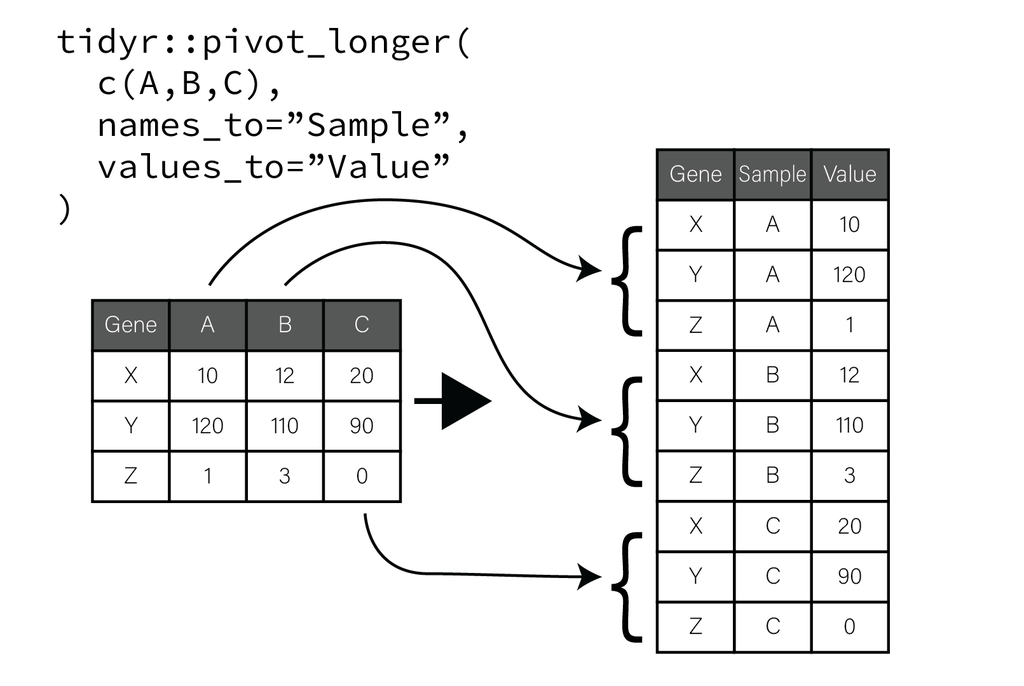

## `tidyr::pivot_longer()`

```r
long_gene_stats <- tidyr::pivot_longer(
  gene_stats,
  ends_with("_stat"), # was c(test1_stat, test2_stat),
  names_to="test",
  values_to="stat"
)
```

```
## # A tibble: 6 × 5
##   gene       test1_p  test2_p test         stat
##   <chr>        <dbl>    <dbl> <chr>       <dbl>
## 1 APOE  0.103        0.000013 test1_stat 12.5
## 2 APOE  0.103        0.000013 test2_stat 34.2
## 3 HOXD1 0.632        0.0421   test1_stat  4.40
## 4 HOXD1 0.632        0.0421   test2_stat 16.3
## 5 SNCA  0.0000000042 0.915    test1_stat 45.7
## 6 SNCA  0.0000000042 0.915    test2_stat  0.757
```

## Pivot, Group, Summarize

- To summarize, `group_by()` on the `test` column and `summarize()` on the `stat` column:

```r
long_gene_stats %>%
  dplyr::group_by(test) %>%
  dplyr::summarize(
    min = min(stat), mean = mean(stat), max = max(stat)
  )
```

```
## # A tibble: 2 × 4
##   test         min  mean   max
##   <chr>      <dbl> <dbl> <dbl>
## 1 test1_stat 4.40   20.9  45.7
## 2 test2_stat 0.757  17.1  34.2
```

## Note: `tidyr::pivot_wider()`

- Inverse of `pivot_longer()` is [`pivot_wider()`](https://tidyr.tidyverse.org/reference/pivot_wider.html)
- If you have variables gathered in single columns like that produced by `pivot_longer()`, reverses process to create tibble with those variables as columns
- Can “reorganize” tibble by first `pivot_longer()` followed by `pivot_wider()`

## Pivot wider illustration

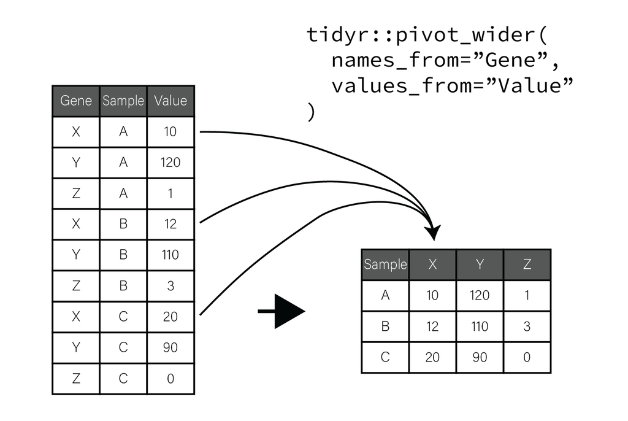

## R in Biology

## R in Biology

- R rose in popularity when [microarray technology](https://www.genome.gov/genetics-glossary/Microarray-Technology) came into widespread use
- A community of biological researchers and data analysts created a collection of software packages called [Bioconductor](https://www.bioconductor.org/)
- R packages form a bridge between:
  - biologists without a computational background and
  - statisticians and bioinformaticians, who invent new methods and implement them as R packages that are easily accessible by all

## Biological Data Overview

## Types of Biological Data

- There are five types of data used in biological data analysis:
  - raw/primary data
  - processed data
  - analysis results
  - metadata
  - annotation data

## Raw/primary data

- The primary observations made by instruments/experiments
- Examples:
  - high-throughput sequencing data
  - mass/charge ratio data from mass spectrometry
  - 16S rRNA sequencing data from metagenomic studies
  - SNPs from genotyping assays,
- Often very large and not efficiently processed using R
- Specialized tools built outside of R are used to first process the primary data into a form that is amenable to analysis
- The most common primary biological data types include [Microarrays], [High Throughput Sequencing] data, and [mass spectrometry](https://en.wikipedia.org/wiki/Mass_spectrometry) data

## Processed data

- The result of any analysis or transformation of primary data into an intermediate, more interpretable form
- For example, in RNASeq:
  1. short reads aligned against a genome
  2. counted against annotated genes
  3. counts form counts matrix of genes x samples
- Processed data does not need to be stored long term if the raw data and code to produce it is available

## Analysis results

- Analysis results aren’t data *per se* but are the results of analysis of primary data or processed data
- Usually what we use to form interpretations of our datasets
- Therefore we must manipulate them in much the same way as any other dataset

## Metadata

- Experiments usually study multiple samples
- Each sample typically has information associated with it
- “Data that is about data” is called *metadata*
- E.g. the information about human subjects included in a study including age at death, whether the person had a disease, the measurements of tissue quality, etc. is the metadata
- The primary and processed data and metadata are usually stored in different files, where the metadata (or *sample information* or *sample data*, etc) will have one column indicating the unique identifier (ID) of each sample.
- The processed data will typically have columns named for each of the sample IDs

## Annotation data

- Includes previously determined information about biological entities, e.g. genes
- Annotation data is publicly available information about the features we measure in our experiments
- Examples:
  - genomic coordinates where genes exist
  - any known functions of those genes
  - the domains found in proteins and their relative sequence
  - gene identifier cross references across different gene naming systems
  - single nucleotide polymorphism genomic locations and associations with traits or diseases

## Information flow in biological data analysis

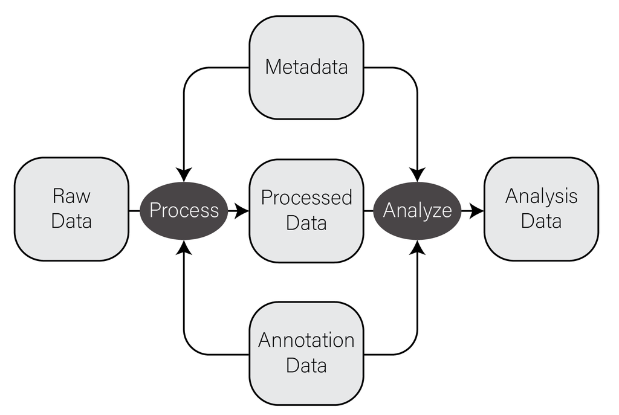